# Broad Analysis I: Boxplot

Laura Plutowski

8.6.2019

## Introduction

Analyzing big data frames becomes a more and more important for working on biological issues. This is the reason why we want to take a look at such an exploratory analysis. Therefore, we focus on data that reports different cellular responses to drug perturbations in cancer treatment. First of all, we will perform a board exploratory analysis over the whole data set. Then we will continue looking at the specific anticancer drug vorinostat.

## 1.Broad Analysis

First of all, we want to explore the whole data from all 15 drug responses including the treated and untreated data sets. Therefor we perform the following analysis steps:

- Boxplot with treated data
- Finding highly variable genes using Seurat
- Analysis of Fold Change matrix
- Different PCA

Before being able to start the analysis, we have to load our data. The data set is taken from the NCI Transcriptional Pharmacodynamics Workbench, including the effect on 13.299 genes from 61 cell lines treated with 15 different anticancer agents. Also, different annotation data is loaded.

```r
library(readr)

Untreated <- readRDS(paste0(wd,"/data/NCI_TPW_gep_untreated.rds"))
Treated <- readRDS(paste0(wd,"/data/NCI_TPW_gep_treated.rds"))
Metadata = read.table(paste0(wd,"/data/NCI_TPW_metadata.tsv"), header = TRUE, sep ="\t", stringsAsFactors = TRUE)
Cellline_annotation = read.table(paste0(wd,"/data/cellline_annotation.tsv"), header = TRUE, sep ="\t", stringsAsFactors = TRUE)
Drug_annotation = read.table(paste0(wd,"/data/drug_annotation.tsv"), header = TRUE, sep ="\t", stringsAsFactors = TRUE)


Treated <- as.data.frame(Treated)
Untreated <- as.data.frame(Untreated)
```

### 1.1 Boxplot from treated data

To visualize our data, we performed a boxplot from the treated data over all 15 drugs.

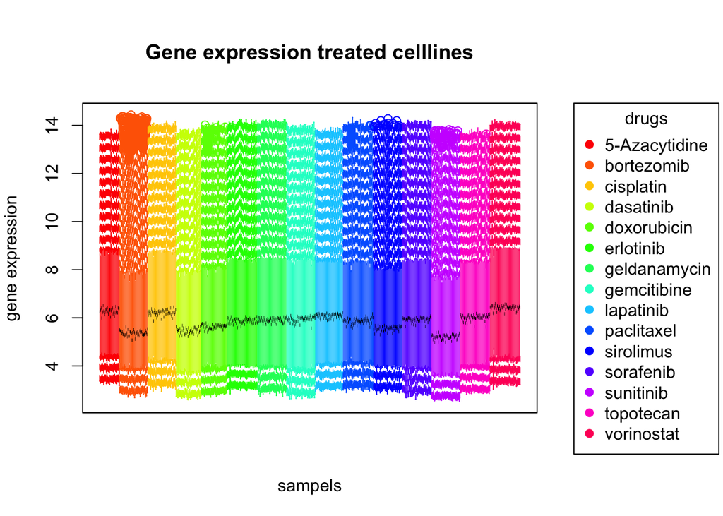

```r
# set graphical parameters
par(mar= c(5, 4, 4, 7) + 0.1)
# levels for coloring
drug <- Metadata$drug
# 15 diffrent colors, for each drug one
palette(rainbow(15))
# Boxplot
par(mar=c(5, 4, 5, 9))
boxplot(Treated, medcol="black", border = drug, col= drug, xlab="sampels", ylab="gene expression",
        main= "Gene expression treated celllines", names= FALSE, xaxt= "n", boxwex=1, boxlty =0)

#add a legend to see which color corresponds to which drug:
levels <- as.factor(levels(drug))
legend("topright", inset = c(-0.4,0), legend= levels(drug), xpd = TRUE, pch=19, col = levels, title = "drugs")
```

The different colors indicate the 15 different anticancer drugs. We can can identify clearly 15 different boxes, each box belonging to one medicine. This indicates that we have batches between all 15 drugs. One reason for this could be, that the experiments were done on different days under slightly different conditions like air pressure or room temperature.

If we normalize the data, we can remove the batch effects. Our plot will change in the following way:

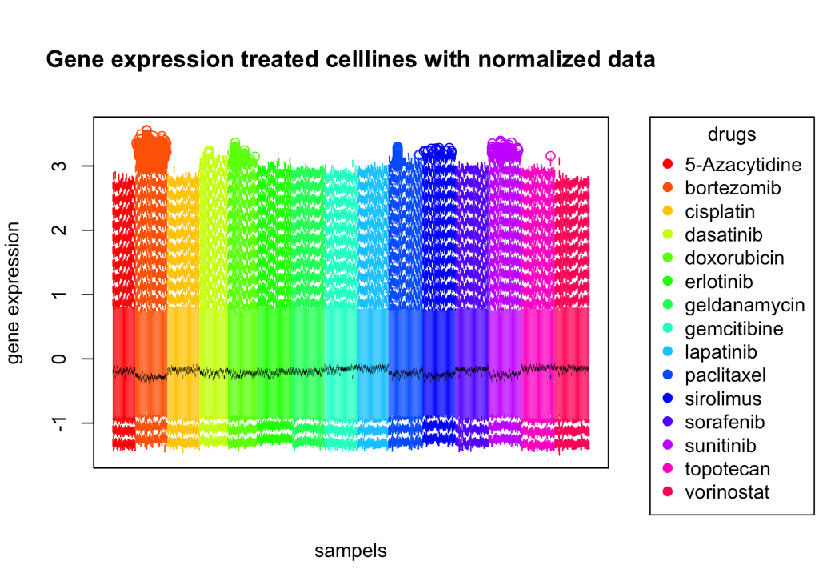

```r
# normalize the data
Untreated_norm <- apply(Untreated, 2, function(x){
  (x - mean(x)) / sd(x)
})


Treated_norm <- apply(Treated, 2, function(x){
  (x - mean(x)) / sd(x)
})


FC <- Treated - Untreated
FC_norm <- apply(FC, 2, function(x){
  (x - mean(x)) / sd(x)
})


# repeat creation of boxplot

# set graphical parameters
par(mar= c(5, 4, 4, 7) + 0.1)
# levels for coloring
drug <- Metadata$drug
# 15 diffrent colors, for each drug one
palette(rainbow(15))
# Boxplot
par(mar=c(5, 4, 5, 9))
boxplot(Treated_norm, medcol="black", border = drug, col= drug, xlab="sampels", ylab="gene expression",
        main= "Gene expression treated celllines with normalized data", names= FALSE, xaxt= "n", boxwex=1, boxlty =0)

#add a legend to see which color corresponds to which drug:
levels <- as.factor(levels(drug))
legend("topright", inset = c(-0.4,0), legend= levels(drug), xpd = TRUE, pch=19, col = levels, title = "drugs")
```

We see that after normalization of the data the batches were removed.

### 1.3 Analysis of Fold Change matrix

The fold change matrix (fold change = FC) describes the changes in gene expression between the treated and the untreated cell lines. First of all, it is visualized by a bar chart, coloring the different drugs.

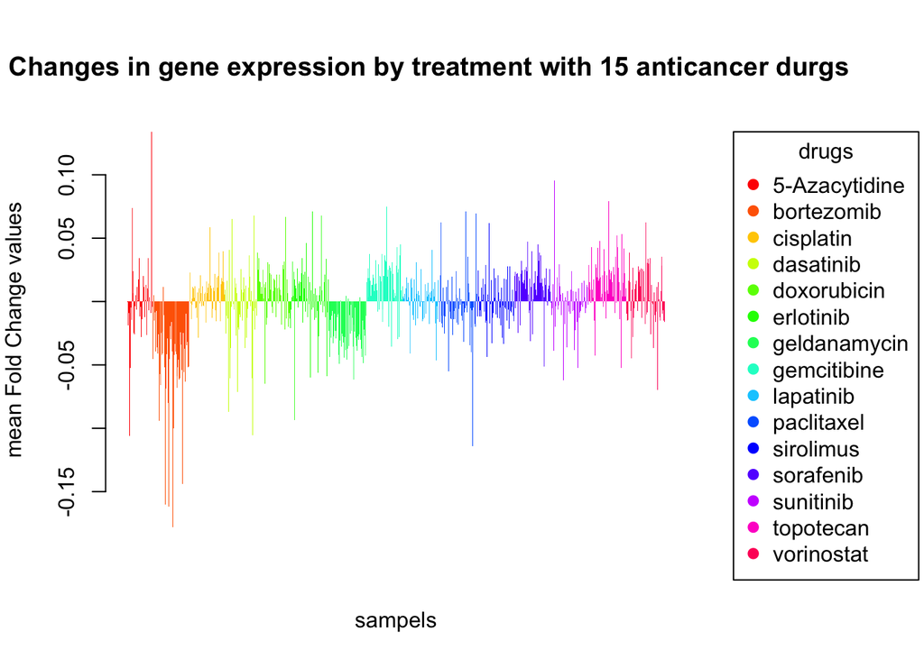

```r
# creat FC data
FC_all = (Treated - Untreated)
FC_all_mean=colMeans(FC_all)

# creat levels for coloring
drug <- Metadata$drug
palette(rainbow(15))

# creat boxplot
par(mar=c(5, 4, 5, 9))
barplot( height = FC_all_mean, names= FALSE, col = drug, border = NA, main= "         Changes in gene expression by treatment with 15 anticancer durgs", xlab="sampels", ylab="mean Fold Change values")

# creat legend
levels <- as.factor(levels(drug))
legend("topright", inset = c(-0.4,0.0), legend= levels(drug), xpd = TRUE, pch=19, col = levels, title = "drugs")
```

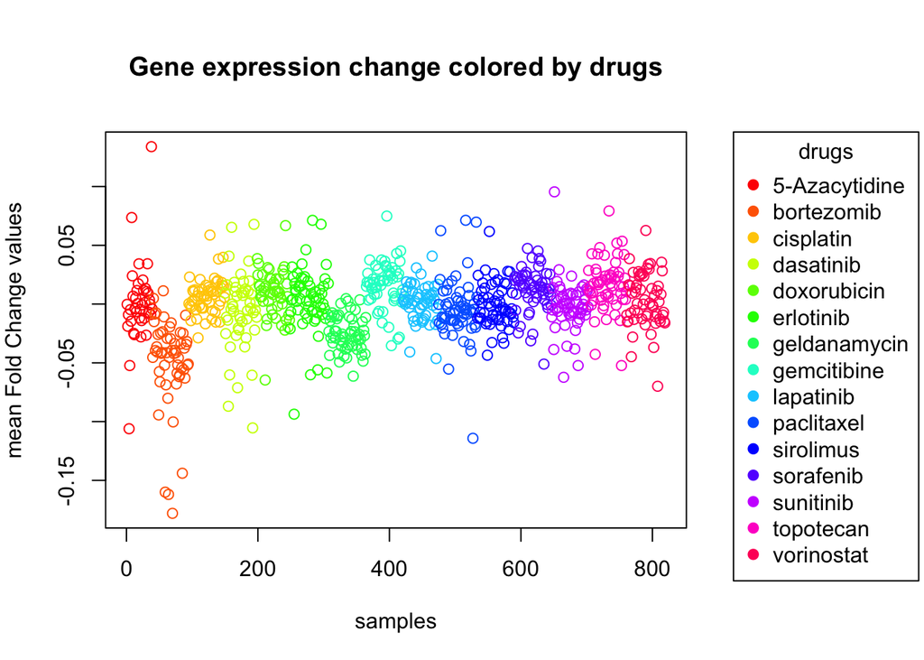

```r
# scatter plot
par(mar=c(5, 4, 5, 9))
plot(FC_all_mean, col= Metadata$drug, main="Gene expression change colored by drugs",xlab="samples",ylab="mean Fold Change values")

# creat legend
drug <- Metadata$drug
levels <- as.factor(levels(drug))
legend("topright", inset = c(-0.4,0), legend= levels(drug), xpd = TRUE, pch=19, col = levels, title = "drugs")
```

The shape of the density plot also shows that the data is normally distributed.

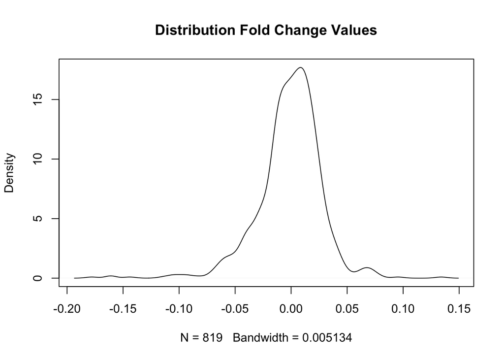

```r
plot(density(FC_all_mean), main= "Distribution Fold Change Values")
```

Coloring the scatter plot according to the tissue types, shows that there is no correlation between FC values and tissue type, when looking all drugs.

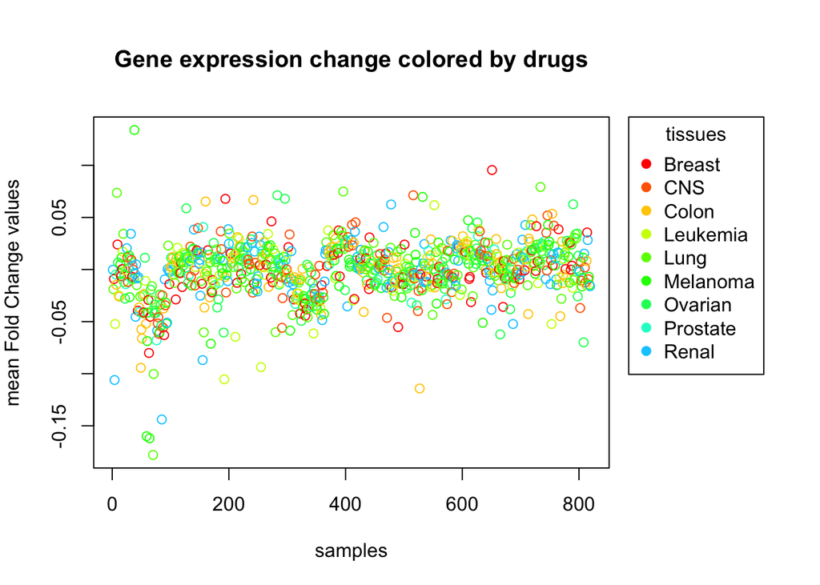

```r
# scatter plot
par(mar=c(5, 4, 5, 9))
plot(FC_all_mean, col= Metadata$tissue,main="Gene expression change colored by drugs",
     xlab="samples",ylab="mean Fold Change values")

# legend
tissue <- Metadata$tissue
levels <- as.factor(levels(tissue))
legend("topright", inset = c(-0.3,0), legend= levels(tissue), xpd = TRUE, pch=19, col = levels,
       title = "tissues")
```

We also can identify the Top 10 values from the FC matrix, which indicate the ten most up and down regulated genes by a specific drug in a specific cell line.

```r
### find all min and max
FC_all_min= (apply(FC_all,2,min))
FC_all_max= (apply(FC_all,2,max))

### sort min and max

# most down regulated gene
largest10_FC_all_min <- (sort(FC_all_min, decreasing = F)[1:10])
largest10_FC_all_min =as.data.frame(largest10_FC_all_min)
knitr::kable(largest10_FC_all_min, caption = "10 smallest FC values")
```

10 smallest FC values

|  | largest10_FC_all_min |
| --- | --- |
| T-47D_vorinostat_5000nM_24h | -9.062011 |
| OVCAR-4_sorafenib_10000nM_24h | -7.601793 |
| NCI-H522_geldanamycin_1000nM_24h | -7.280544 |
| MALME-3M_vorinostat_5000nM_24h | -6.864732 |
| OVCAR-4_doxorubicin_1000nM_24h | -6.843617 |
| UACC-257_vorinostat_5000nM_24h | -6.813984 |
| OVCAR-4_bortezomib_100nM_24h | -6.608203 |
| NCI-H226_bortezomib_100nM_24h | -6.447166 |
| COLO-205_bortezomib_100nM_24h | -6.391190 |
| OVCAR-3_sirolimus_100nM_24h | -6.353995 |

```r
# most up regulated genes
largest10_FC_all_max <- (sort(FC_all_max, decreasing = T)[1:10])
largest10_FC_all_max =as.data.frame(largest10_FC_all_max)
knitr::kable(largest10_FC_all_max, caption = "10 highest FC values")
```

10 highest FC values

|  | largest10_FC_all_max |
| --- | --- |
| T-47D_bortezomib_100nM_24h | 9.493492 |
| T-47D_vorinostat_5000nM_24h | 9.162674 |
| SNB-75_bortezomib_100nM_24h | 9.078432 |
| SK-MEL-28_vorinostat_5000nM_24h | 8.906626 |
| NCI-H226_doxorubicin_1000nM_24h | 8.833774 |
| SF-268_bortezomib_100nM_24h | 8.823692 |
| OVCAR-3_bortezomib_100nM_24h | 8.681822 |
| HS-578T_bortezomib_100nM_24h | 8.604213 |
| COLO-205_geldanamycin_1000nM_24h | 8.578627 |
| 786-0_bortezomib_100nM_24h | 8.529357 |

Here we can see, that see that vorinostat (occurs 3 times for downregulated and 2 times for up regulated), bortezomib (occurs 3 times for downregulated and 6 times for up regulated) seem to have the biggest effects on the gene expression in the cell lines. Moreover, the OVCAR-4 cell line, which bellows to the ovarian cancer, occurs the most (3 times) in the down regulated data.